# Etude de cas MEDADOM : Analyse exploratoire d'un jeu de données sur une population d'adultes

## Table des matières

- 1. Introduction
- 2. Préparation et nettoyage des données
  - 2.1. Prévisualisation des données
  - 2.2. Vérification du typage des données et gestion des valeurs manquantes
- 3. Analyse descriptive initiale du jeu de données
  - 3.1. Création d'outil d'analyse
  - 3.2. Variables numériques
  - 3.3. Variables catégorielles
- 4. Création et analyse de nouveaux champs
  - 4.1. Transformations du jeu de données - création de nouveaux champs
  - 4.2. Analyse des nouveaux champs catégoriels
  - 4.3. Analyse du nouveau champ numérique
- 5. Analyse des relations et corrélations entre les champs
  - 5.1. Corrélations entre champs numériques
  - 5.2. Relations entre champs catégoriels et revenus
- 6. Analyse Approfondie des Facteurs Influents
  - 6.1. Identification des facteurs influents
  - 6.2. Visualisation des interactions entre facteurs influents
- 7. Conclusion et synthèse

## 1. Introduction

L'objectif de ce notebook est de réaliser une analyse exploratoire détaillée du jeu de données "adult.csv". L'analyse visera à extraire des insights pertinents et à comprendre en profondeur la structure et les caractéristiques de ces données.

L'étude adoptera une démarche exploratoire, en commençant par une exploration ouverte des données, suivie d'une analyse plus structurée basée sur les premières découvertes.

```python
# Imports de tous les packages utilisés dans ce notebook
import pandas as pd
import seaborn as sns
import matplotlib.pyplot as plt
import numpy as np
from sklearn.ensemble import RandomForestClassifier
from sklearn.model_selection import train_test_split
from sklearn.model_selection import GridSearchCV
from sklearn.metrics import accuracy_score, classification_report, confusion_matrix, roc_auc_score, roc_curve
```

## 2. Préparation et nettoyage des données

### 2.1. Prévisualisation des données

Tout d'abord, on charge les données pour analyser leur structure, leur contenu et de potentielles anomalies.

```python
# Chargement du jeu de données
adult_df = pd.read_csv('./Excel_files/adult.csv')

# Affichage de la structure du dataframe
adult_df
```

|  | age | workclass | fnlwgt | education | educational-num | marital-status | occupation | relationship | race | gender | capital-gain | capital-loss | hours-per-week | native-country | income |
| --- | --- | --- | --- | --- | --- | --- | --- | --- | --- | --- | --- | --- | --- | --- | --- |
| 0 | 25 | Private | 226802 | 11th | 7 | Never-married | Machine-op-inspct | Own-child | Black | Male | 0 | 0 | 40 | United-States | <=50K |
| 1 | 38 | Private | 89814 | HS-grad | 9 | Married-civ-spouse | Farming-fishing | Husband | White | Male | 0 | 0 | 50 | United-States | <=50K |
| 2 | 28 | Local-gov | 336951 | Assoc-acdm | 12 | Married-civ-spouse | Protective-serv | Husband | White | Male | 0 | 0 | 40 | United-States | >50K |
| 3 | 44 | Private | 160323 | Some-college | 10 | Married-civ-spouse | Machine-op-inspct | Husband | Black | Male | 7688 | 0 | 40 | United-States | >50K |
| 4 | 18 | ? | 103497 | Some-college | 10 | Never-married | ? | Own-child | White | Female | 0 | 0 | 30 | United-States | <=50K |
| ... | ... | ... | ... | ... | ... | ... | ... | ... | ... | ... | ... | ... | ... | ... | ... |
| 48837 | 27 | Private | 257302 | Assoc-acdm | 12 | Married-civ-spouse | Tech-support | Wife | White | Female | 0 | 0 | 38 | United-States | <=50K |
| 48838 | 40 | Private | 154374 | HS-grad | 9 | Married-civ-spouse | Machine-op-inspct | Husband | White | Male | 0 | 0 | 40 | United-States | >50K |
| 48839 | 58 | Private | 151910 | HS-grad | 9 | Widowed | Adm-clerical | Unmarried | White | Female | 0 | 0 | 40 | United-States | <=50K |
| 48840 | 22 | Private | 201490 | HS-grad | 9 | Never-married | Adm-clerical | Own-child | White | Male | 0 | 0 | 20 | United-States | <=50K |
| 48841 | 52 | Self-emp-inc | 287927 | HS-grad | 9 | Married-civ-spouse | Exec-managerial | Wife | White | Female | 15024 | 0 | 40 | United-States | >50K |

48842 rows × 15 columns

ATTENTION : L'échantillon de données n'étant pas exhaustif dans ces champs et dans ses valeurs, et ses conditions de création étant inconnues, tous les résultats d'analyses qui vont suivre seront à prendre avec du recul. Ils ne représentent pas forcèment la réalité, mais seulement les tendances du groupe d'individus sur lequel le jeu de données est basé.

### 2.2. Vérification du typage des données et gestion des valeurs manquantes

Pour vérifier notre hypothèse sur les '?', on affiche les valeurs manquantes ('NaN', 'NULL', 'None'...)

```python
# Création d'un dataframe pour afficher lu nombre de valeurs manquantes de chaque champ en format horizontal
missing_values_df = pd.DataFrame(adult_df.isna().sum()).transpose()
missing_values_df.index = ['Nombre de valeurs manquantes']
missing_values_df
```

|  | age | workclass | fnlwgt | education | educational-num | marital-status | occupation | relationship | race | gender | capital-gain | capital-loss | hours-per-week | native-country | income |
| --- | --- | --- | --- | --- | --- | --- | --- | --- | --- | --- | --- | --- | --- | --- | --- |
| Nombre de valeurs manquantes | 0 | 0 | 0 | 0 | 0 | 0 | 0 | 0 | 0 | 0 | 0 | 0 | 0 | 0 | 0 |

On ne compte donc aucune valeur manquante en se basant sur les valeurs par défault.  
Rééssayons en cherchant les valeurs **'?'** dans le jeu de données. Affichons par la même occasion les types des données de chaque champ pour nous assurer de leur convenance.

```python
# Création d'un dataFrame pour afficher les types de données et les valeurs manquantes
data_overview = pd.DataFrame({
    'Champ': adult_df.columns,
    'Type': adult_df.dtypes,
    "Nombre de valeurs manquantes ('?')": adult_df.apply(lambda x: (x == '?').sum()),
    "Pourcentage de valeurs manquantes ('?')": round(adult_df.apply(lambda x: (x == '?').sum()) * 100 / len(adult_df), 2),
}).reset_index()

data_overview
```

|  | index | Champ | Type | Nombre de valeurs manquantes ('?') | Pourcentage de valeurs manquantes ('?') |
| --- | --- | --- | --- | --- | --- |
| 0 | age | age | int64 | 0 | 0.00 |
| 1 | workclass | workclass | object | 2799 | 5.73 |
| 2 | fnlwgt | fnlwgt | int64 | 0 | 0.00 |
| 3 | education | education | object | 0 | 0.00 |
| 4 | educational-num | educational-num | int64 | 0 | 0.00 |
| 5 | marital-status | marital-status | object | 0 | 0.00 |
| 6 | occupation | occupation | object | 2809 | 5.75 |
| 7 | relationship | relationship | object | 0 | 0.00 |
| 8 | race | race | object | 0 | 0.00 |
| 9 | gender | gender | object | 0 | 0.00 |
| 10 | capital-gain | capital-gain | int64 | 0 | 0.00 |
| 11 | capital-loss | capital-loss | int64 | 0 | 0.00 |
| 12 | hours-per-week | hours-per-week | int64 | 0 | 0.00 |
| 13 | native-country | native-country | object | 857 | 1.75 |
| 14 | income | income | object | 0 | 0.00 |

On note que le typage des données peut être amelioré en convertissant les champs catégoriels initialement de type **'object'** en type **'category'**. Cette conversion permettrait d'améliorer l'efficacité de la mémoire et accélérer certaines opérations sur ces colonnes.  
Effectuons cette convertion.

```python
# Analyse des types de données
data_types = adult_df.dtypes

# Conversion des types de données pour les colonnes catégorielles
for col in adult_df.select_dtypes(include='object').columns:
    adult_df[col] = adult_df[col].astype('category')

# Affichage des types de données avant et après conversion
data_types_comparison = pd.DataFrame({'Avant conversion': data_types,
                                      'Après conversion': adult_df.dtypes})
data_types_comparison
```

|  | Avant conversion | Après conversion |
| --- | --- | --- |
| age | int64 | int64 |
| workclass | object | category |
| fnlwgt | int64 | int64 |
| education | object | category |
| educational-num | int64 | int64 |
| marital-status | object | category |
| occupation | object | category |
| relationship | object | category |
| race | object | category |
| gender | object | category |
| capital-gain | int64 | int64 |
| capital-loss | int64 | int64 |
| hours-per-week | int64 | int64 |
| native-country | object | category |
| income | object | category |

On tire donc deux conclusions de cette étude.  
1 - Le typage des données est maintenant optimal. Il n'y aura plus de modifications a effectuer de ce côté.  
2 - On trouve des valeurs manquantes ('?') dans 3 champs : 'workclass', 'occupation' et 'native-country'. Elles représentent un pourcentage non négligeable et elles devront être exclues de certaines analyses.

## 3. Analyse descriptive initiale du jeu de données

### 3.1. Création d'outil d'analyse

```python
# Analyse statistique de la distribution pour les variables numériques
adult_df.describe()
```

|  | age | fnlwgt | educational-num | capital-gain | capital-loss | hours-per-week |
| --- | --- | --- | --- | --- | --- | --- |
| count | 48842.00 | 48842.00 | 48842.00 | 48842.00 | 48842.00 | 48842.00 |
| mean | 38.64 | 189664.13 | 10.08 | 1079.07 | 87.50 | 40.42 |
| std | 13.71 | 105604.03 | 2.57 | 7452.02 | 403.00 | 12.39 |
| min | 17.00 | 12285.00 | 1.00 | 0.00 | 0.00 | 1.00 |
| 25% | 28.00 | 117550.50 | 9.00 | 0.00 | 0.00 | 40.00 |
| 50% | 37.00 | 178144.50 | 10.00 | 0.00 | 0.00 | 40.00 |
| 75% | 48.00 | 237642.00 | 12.00 | 0.00 | 0.00 | 45.00 |
| max | 90.00 | 1.5e+06 | 16.00 | 99999.00 | 4356.00 | 99.00 |

Ici, on voit bien que cette analyse n'est pas interessante. En effet, nous ne prenons pas en compte la pondération liée au champ fnlwgt.  
On se trouve donc devant deux options pour visualiser la donnée de manière complète.

- Modifier le dataset. Il s'agirait de dupliquer chaque ligne du dataset en fonction de sa pondération **'fnlwgt'**. Cela signifie que si une ligne a une pondération de **'fnlwgt'** = 3, cette ligne serait répliquée deux fois supplémentaires. Cependant, cette méthode peut conduire à un dataset extrêmement grand et serait impraticable, surtout pour les grandes valeurs de **'fnlwgt'**.
- Appliquer la pondération lors des analyses. On peut utiliser **'fnlwgt'** comme poids pour chaque observation. Cela permettra de refléter plus fidèlement la distribution réelle de la population.

L'approche de pondération lors des analyses est plus pratique et conserve l'intégrité des données originales tout en tenant compte de la représentativité de chaque observation.  
Créons donc une fonction describe qui prend en compte cette pondération, afin d'avoir un meilleur aperçu des données.

```python
# Fonction de description statistique des champs numériques d'un jeu de données
def numeric_ponderated_describe(data, weight_col):

    # Initialision d'un DataFrame pour les résultats
    results = pd.DataFrame()

    # Pour chaque colonne numérique dans le dataset
    for col in data.select_dtypes(include=[np.number]).columns:
        if col != weight_col:
            # Calcul de la somme pondérée
            weighted_count = data[weight_col].sum()

            # Calcul de la moyenne pondérée
            weighted_mean = (data[col] * data[weight_col]).sum() / data[weight_col].sum()

            # Calcul de l'écart-type pondéré
            weighted_var = ((data[weight_col] * (data[col] - weighted_mean) ** 2).sum() / data[weight_col].sum())
            weighted_std = np.sqrt(weighted_var)

            # Tri des données et calcul de la somme cumulative des poids
            sorted_data = data.sort_values(weight_col)
            cumulative_weights = sorted_data[weight_col].cumsum()
            total_weight = sorted_data[weight_col].sum()

            # Calcul des quartiles pondérés
            q25 = sorted_data.loc[cumulative_weights >= 0.25 * total_weight, col].iloc[0]
            q50 = sorted_data.loc[cumulative_weights >= 0.50 * total_weight, col].iloc[0]
            q75 = sorted_data.loc[cumulative_weights >= 0.75 * total_weight, col].iloc[0]

            min_val = data[col].min()
            max_val = data[col].max()

            # Ajout des résultats dans le DataFrame
            results[col] = [weighted_count, weighted_mean, weighted_std, min_val, q25, q50, q75, max_val]

    results.index = ['count', 'mean', 'std', 'min', '25%', '50%', '75%', 'max']

    return results

# Fonction de description statistique des champs catégoriels d'un jeu de données
def categorical_ponderated_describe(data, weight_col):

    # Initialisation d'un DataFrame pour les résultats
    results = pd.DataFrame()

    # Pour chaque colonne catégorielle dans le dataset
    for col in data.select_dtypes(include=['category']).columns:

        # Calcul du nombre de catégories uniques
        unique_count = data[col].nunique()

        # Calcul de la fréquence pondérée pour chaque catégorie
        freq_pond = data.groupby(col, observed=True)[weight_col].sum()

        # Calcul de la somme pondérée
        weighted_count = freq_pond.sum()

        # Calcul de la catégorie avec la plus grande somme de poids
        top_pond = freq_pond.idxmax()

        # Calcul de la fréquence pondérée maximale du mode
        freq_mode_pond = freq_pond.max()

        # Ajout des résultats dans le DataFrame
        results[col] = [weighted_count, unique_count, top_pond, freq_mode_pond]

    results.index = ['count', 'unique', 'top', 'freq']
    return results

def ponderated_describe(data, weight_col, is_numeric=True):
    # Ajustement du format d'affichage
    pd.set_option('display.float_format', lambda x: f'{x:.2f}' if abs(x) < 1e6 else f'{x:.1e}')

    if is_numeric:
        return numeric_ponderated_describe(data, weight_col)
    else:
        return categorical_ponderated_describe(data, weight_col)
```

### 3.2. Variables numériques

```python
# Analyse statistique pondérée de la distribution pour les variables numériques
ponderated_describe(adult_df, 'fnlwgt')
```

|  | age | educational-num | capital-gain | capital-loss | hours-per-week |
| --- | --- | --- | --- | --- | --- |
| count | 9.3e+09 | 9.3e+09 | 9.3e+09 | 9.3e+09 | 9.3e+09 |
| mean | 38.06 | 10.02 | 1063.69 | 86.52 | 40.33 |
| std | 13.52 | 2.61 | 7378.74 | 400.00 | 12.14 |
| min | 17.00 | 1.00 | 0.00 | 0.00 | 1.00 |
| 25% | 34.00 | 12.00 | 0.00 | 0.00 | 35.00 |
| 50% | 23.00 | 13.00 | 0.00 | 0.00 | 60.00 |
| 75% | 51.00 | 13.00 | 0.00 | 0.00 | 40.00 |
| max | 90.00 | 16.00 | 99999.00 | 4356.00 | 99.00 |

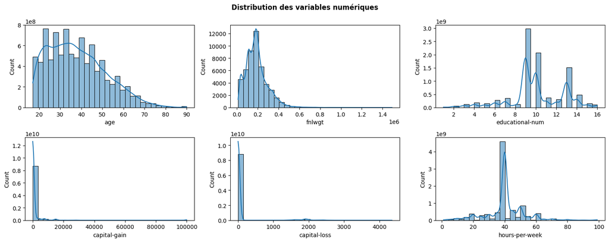

```python
# Analyse schématique pondérée de la distribution pour les variables numériques

fig, axes = plt.subplots(nrows=2, ncols=3, figsize=(15, 6))
fig.suptitle('Distribution des variables numériques', weight = 'bold')

num_cols = adult_df.select_dtypes(include=['int64']).columns

for i, col in enumerate(num_cols):
    # On n'applique pas la pondération pour la colonne fnlwgt pondérante
    if (i//3, i%3) == (0, 1):
        sns.histplot(adult_df[col], ax=axes[i//3, i%3], kde=True, bins=30)
    else:
        sns.histplot(adult_df, x=col, weights='fnlwgt', ax=axes[i//3, i%3], bins=30, kde=True)

plt.tight_layout()
plt.show()
```

On note plusieurs points importants pour les futures analyses:

- l'age varie entre 17 et 90 ans
- Le champ **'fnlwgt'** a un écart type très élevé et donc une très grande variation. Il faudra absolument l'inclure aux analyses pour obtenir des résultats cohérents.
- Les champs **'capital gain'** et **'capital loss'** sont très majoritairement vides. Les valeurs maximales sont cependant très élevées ce qui indique la présence de valeures extrêmes. Il faudra garder ce point en tête lors des analyses.
- La majorité des individus travaillent autour de 40h par semaine. On pourra donc définir 40h comme le temps de travail classique pour un salarié à temps plein.

### 3.3. Variables catégorielles

```python
# Analyse statistique pondérée de la distribution pour les variables catégorielles
cat_cols = adult_df.select_dtypes(include=['category']).columns
ponderated_describe(adult_df, 'fnlwgt', is_numeric=False)
```

|  | workclass | education | marital-status | occupation | relationship | race | gender | native-country | income |
| --- | --- | --- | --- | --- | --- | --- | --- | --- | --- |
| count | 9263575662 | 9263575662 | 9263575662 | 9263575662 | 9263575662 | 9263575662 | 9263575662 | 9263575662 | 9263575662 |
| unique | 9 | 16 | 7 | 15 | 6 | 5 | 2 | 42 | 2 |
| top | Private | HS-grad | Married-civ-spouse | Craft-repair | Husband | White | Male | United-States | <=50K |
| freq | 6532642319 | 2977279353 | 4180186446 | 1175086915 | 3690703578 | 7805108812 | 6259887256 | 8202805677 | 7060920057 |

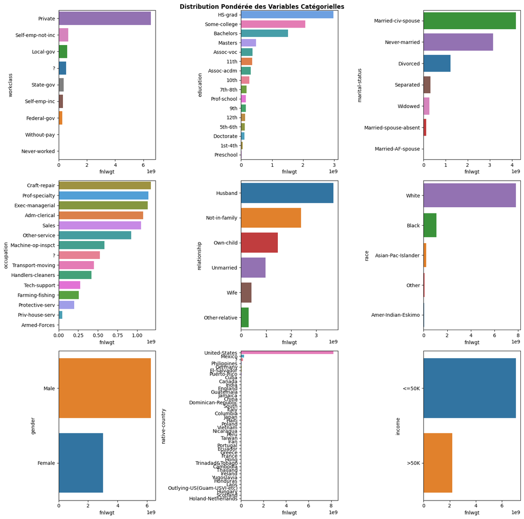

```python
# Analyse schématique pondérée de la distribution pour les variables catégorielles
fig, axes = plt.subplots(nrows=3, ncols=3, figsize=(15, 15))
fig.suptitle('Distribution Pondérée des Variables Catégorielles', weight='bold')

for i, col in enumerate(cat_cols):
    # Groupage, calcul de la somme de 'fnlwgt' et tri des catégories par poids total
    grouped_data = adult_df.groupby(col, observed=True)['fnlwgt'].sum().sort_values(ascending=False).reset_index()

    sns.barplot(x='fnlwgt', y=col, data=grouped_data, ax=axes[i//3, i%3], order=grouped_data[col], hue=col)

plt.tight_layout()
plt.show()
```

Encore une fois, plusieurs points importants ressortent:

- La grande majorité des individus dans ce dataset sont identifiés comme 'White'.
- La répartition entre les genres pourrait fournir des insights sur la diversité des genres dans l'échantillon.
- La grande majorité des individus sont originaires des États-Unis.
- Le champ 'income' qui semble être la cible pour la majorité des études possibles sur ce dataset est majoritairement égal à '<=50K'. Une telle répartition est logique au vu de la nature de ces données, mais cela devra bien être pris en compte dans les analyses.

## 4. Création et analyse de nouveaux champs

### 4.1. Transformations du jeu de données - création de nouveaux champs

Créons de nouveaux champs permettant de grouper les données différement afin d'augmenter nos possibilités d'analyses.

Les champs que nous allons créer sont les suivants:

- **"native-continent"** : champ regroupant les individus par continent (on se base ici sur le champ "native-country" regroupant les individus par pays).
- **"age-group"** : champ regoupant les individus par tranche d'âge.

on prend :  
[0;25[ : Young adult,  
[25;45[ : Adult,  
[45;65[ : Senior,  
[65;100[ : Very Senior

- **"hours-per-week-group"** : champ regoupant les individus par heures de travail.

On prend :  
[0;20[ : Part-time,  
[20;40[ : Full-time,  
[40;60[ : Overtime,  
[60;100[ : Intensive work

- **"capital-diff"** : champ regroupant les deux champs existants "capital-loss" et "capital-gain" pour en ressortir la variation globale du capital.

A noter qu'un nouveau champ indiquant le salaire moyen dans le pays de l'individu serait interessant mais nécessiterait un croisement avec un autre jeu de données.

```python
def categorize_country(country):
    if country in ['United-States', 'Canada', 'Outlying-US(Guam-USVI-etc)']:
        return 'North america'
    elif country in ['Mexico', 'Cuba', 'Jamaica', 'Dominican-Republic', 'El-Salvador', 'Puerto-Rico', 'Honduras', 'Guatemala', 'Nicaragua', 'Haiti', 'Trinadad&Tobago', 'Peru', 'Ecuador', 'Columbia']:
        return 'Central and south america'
    elif country in ['England', 'Germany', 'Portugal', 'Italy', 'Poland', 'France', 'Scotland', 'Greece', 'Ireland', 'Yugoslavia', 'Hungary', 'Holand-Netherlands']:
        return 'Europe'
    elif country in ['India', 'China', 'Japan', 'Taiwan', 'Iran', 'Philippines', 'Vietnam', 'Laos', 'Thailand', 'Cambodia', 'Hong']:
        return 'Asia'
    elif country in ['South']:
        return 'Africa'
    else:
        # On a ici les pays notés : '?'
        return 'Unknown'

# Regroupement des pays par continent
adult_df['native-continent'] = adult_df['native-country'].apply(categorize_country).astype('category')

# Regroupement de l'âge
age_bins = [0, 25, 45, 65, 100]
age_labels = ['Young adult', 'Adult', 'Senior', 'Very senior']
adult_df['age-group'] = pd.cut(adult_df['age'], bins=age_bins, labels=age_labels, right=False)

# Regroupement des heures de travail hebdomadaires
hours_bins = [0, 20, 40, 60, 100]
hours_labels = ['Part-time', 'Full-time', 'Overtime', 'Intensive work']
adult_df['hours-per-week-group'] = pd.cut(adult_df['hours-per-week'], bins=hours_bins, labels=hours_labels, right=False)

# Combinaison du gain et de la perte de capital
adult_df['capital-diff'] = adult_df['capital-gain'] - adult_df['capital-loss']

adult_df.head()
```

|  | age | workclass | fnlwgt | education | educational-num | marital-status | occupation | relationship | race | gender | capital-gain | capital-loss | hours-per-week | native-country | income | native-continent | age-group | hours-per-week-group | capital-diff |
| --- | --- | --- | --- | --- | --- | --- | --- | --- | --- | --- | --- | --- | --- | --- | --- | --- | --- | --- | --- |
| 0 | 25 | Private | 226802 | 11th | 7 | Never-married | Machine-op-inspct | Own-child | Black | Male | 0 | 0 | 40 | United-States | <=50K | North america | Adult | Overtime | 0 |
| 1 | 38 | Private | 89814 | HS-grad | 9 | Married-civ-spouse | Farming-fishing | Husband | White | Male | 0 | 0 | 50 | United-States | <=50K | North america | Adult | Overtime | 0 |
| 2 | 28 | Local-gov | 336951 | Assoc-acdm | 12 | Married-civ-spouse | Protective-serv | Husband | White | Male | 0 | 0 | 40 | United-States | >50K | North america | Adult | Overtime | 0 |
| 3 | 44 | Private | 160323 | Some-college | 10 | Married-civ-spouse | Machine-op-inspct | Husband | Black | Male | 7688 | 0 | 40 | United-States | >50K | North america | Adult | Overtime | 7688 |
| 4 | 18 | ? | 103497 | Some-college | 10 | Never-married | ? | Own-child | White | Female | 0 | 0 | 30 | United-States | <=50K | North america | Young adult | Full-time | 0 |

### 4.2. Analyse des nouveaux champs catégoriels

```python
# Analyse statistique pondérée de la distribution pour les nouvelles variables catégorielles
new_categorical_values = ['native-continent', 'age-group', 'hours-per-week-group']

columns_for_ponderated_description = new_categorical_values.copy()
columns_for_ponderated_description.append('fnlwgt')

ponderated_describe(adult_df[columns_for_ponderated_description], 'fnlwgt', is_numeric=False)
```

|  | native-continent | age-group | hours-per-week-group |
| --- | --- | --- | --- |
| count | 9263575662 | 9263575662 | 9263575662 |
| unique | 6 | 4 | 4 |
| top | North america | Adult | Overtime |
| freq | 8240058451 | 4766737288 | 6362755486 |

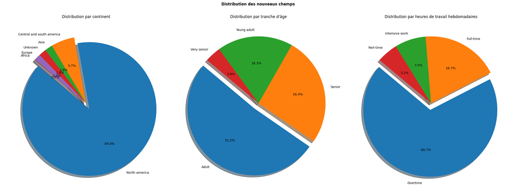

```python
# Analyse schématique pondérée de la distribution pour les variables catégorielles
fig, axes = plt.subplots(nrows=1, ncols=3, figsize=(23, 9))
fig.suptitle('Distribution des nouveaux champs', weight='bold')

for i, field_name in enumerate(new_categorical_values):
    grouped_data = adult_df.groupby(field_name, observed=True)['fnlwgt'].sum().sort_values(ascending=False).reset_index()
    num_categories = len(grouped_data[field_name].unique())
    explode = [0.1 if i == 0 else 0 for i in range(num_categories)]
    axes[i].pie(grouped_data['fnlwgt'], explode=explode, labels=grouped_data[field_name], autopct='%1.1f%%', shadow=True, startangle=140)

axes[0].set_title('Distribution par continent')

axes[1].set_title('Distribution par tranche d\'âge', )

axes[2].set_title('Distribution par heures de travail hebdomadaires')

plt.tight_layout()
```

Grâce à la création de ces nouveaux champs, des échantillons clairs de populations ressortent. La création des champs de regroupement par tranche d'âge et par heures de travail est selon moi un ajout très utile peu importe l'étude visant à être menée sur le jeu de données.

En revanche, le regroupement par continent n'a pas l'air d'apporter une réelle plus value. Les données étant très polarisées et représentant majoritairement des individus des états-unis, ce jeu de données n'aura sûrement un interêt que pour une étude au sein de ce pays.

### 4.3. Analyse du nouveau champ numérique

```python
# Distribution statistique pondérée du nouveau champ: 'capital-diff'
ponderated_describe(adult_df[['capital-diff', 'fnlwgt']], 'fnlwgt')
```

|  | capital-diff |
| --- | --- |
| count | 9.3e+09 |
| mean | 977.17 |
| std | 7402.02 |
| min | -4356.00 |
| 25% | 0.00 |
| 50% | 0.00 |
| 75% | 0.00 |
| max | 99999.00 |

Ce nouveau champ permet une vision plus claire et plus directe sur la notion de variation de capital du jeu de données. On voit donc que le capital est très majoritairement inchangé mais peut grandement varier chez de rares individus.

## 5. Analyse des relations et corrélations entre les champs

### 5.1. Corrélations entre champs numériques

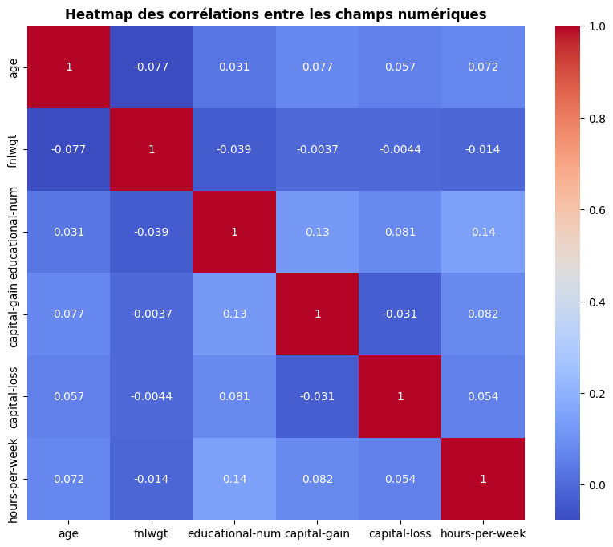

```python
# Calcul des corrélations entre les champs numériques
correlations = adult_df[num_cols].corr()

# Création d'une heatmap des corrélations entre les champs numériques
plt.figure(figsize=(10, 8))
sns.heatmap(correlations, annot=True, cmap='coolwarm')
plt.title('Heatmap des corrélations entre les champs numériques', weight='bold')
plt.show()
```

La heatmap montre les corrélations linéaires entre les variables numériques. Bien qu'elle ne prenne pas en compte la pondération **'fnlwgt'**, cette visualisation fournit un aperçu initial des relations potentielles entre ces variables.  
Les corrélations ne sont pas fortement marquées, ce qui suggère que ces variables numériques peuvent contribuer de manière distincte à la compréhension des caractéristiques des individus.

### 5.2. Relations entre champs catégoriels et revenus

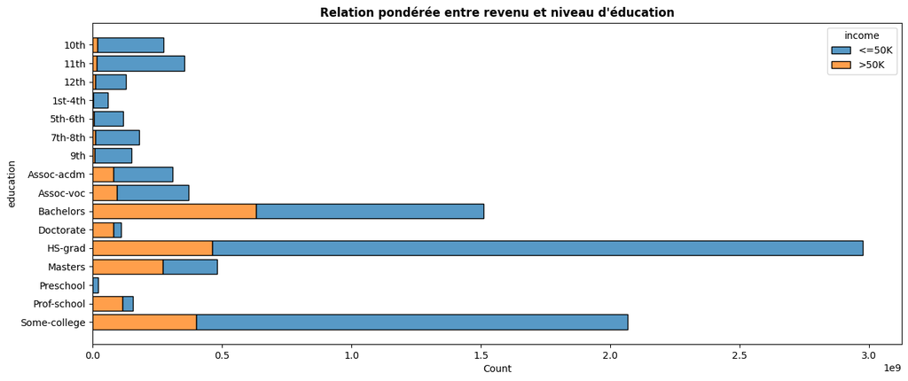

```python
# Création d'un histogramme montrant la relation pondérée entre le revenu et le niveau d'éducation de l'individu
plt.figure(figsize=(15, 6))
sns.histplot(data=adult_df, y='education', hue='income', weights='fnlwgt', multiple="stack", shrink=0.8)
plt.title('Relation pondérée entre revenu et niveau d\'éducation', weight='bold')
plt.show()
```

Les niveaux d'éducation supérieurs tendent à être associés à des revenus plus élevés, confirmant l'hypothèse classique sur l'impact de l'éducation sur le revenu.

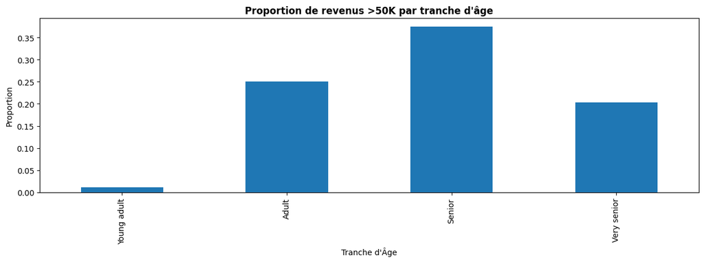

```python
# Création d'un histogramme montrant la relation pondérée entre le revenu et la tranche d'âge de l'individu
income_above_50k = adult_df[adult_df['income'] == '>50K']

# Calcul des proportions de revenus > 50K par tranche d'âge
age_group_weighted_proportions = income_above_50k.groupby('age-group', observed=False)['fnlwgt'].sum() / adult_df.groupby('age-group', observed=False)['fnlwgt'].sum()
age_group_weighted_proportions = age_group_weighted_proportions.sort_index()

# Graphique en barres pour les proportions
plt.figure(figsize=(15, 4))
age_group_weighted_proportions.plot(kind='bar')
plt.title('Proportion de revenus >50K par tranche d\'âge', weight='bold')
plt.ylabel('Proportion')
plt.xlabel('Tranche d\'Âge')
plt.show()
```

Les adultes et les seniors présentent une proportion plus importante de revenus supérieurs à 50K. Cela peut indiquer que l'expérience professionnelle et l'ancienneté influencent positivement le revenu jusqu'à un certain stade. Passé un certain stade d'ancienneté (autour de 65 ans), la proportion d'individus touchant plus de 50k baisse. Cela peut s'expliquer par une transition graduelle vers la retraite de ces individus.

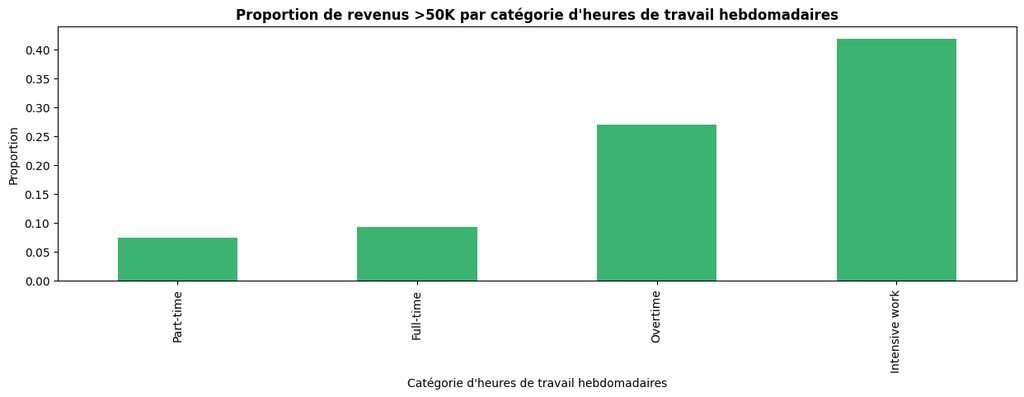

```python
hours_weighted_proportions = income_above_50k.groupby('hours-per-week-group', observed=False)['fnlwgt'].sum() / adult_df.groupby('hours-per-week-group', observed=False)['fnlwgt'].sum()
hours_weighted_proportions = hours_weighted_proportions.sort_index()

# Graphique en barres pour les proportions pondérées par heures de travail
plt.figure(figsize=(15, 4))
hours_weighted_proportions.plot(kind='bar', color='mediumseagreen')
plt.title('Proportion de revenus >50K par catégorie d\'heures de travail hebdomadaires', weight='bold')
plt.ylabel('Proportion')
plt.xlabel('Catégorie d\'heures de travail hebdomadaires')
plt.show()
```

La proportion d'individus gagnant plus de 50k est donc en moyenne proportionnelle au temps de travail hebdomadaire. Cela suggère que les heures de travail plus longues sont associées à des revenus plus élevés. Les deux champs sont donc liés.

Deux possibilités peuvent expliquer ce phénomène. Soit les personnes travaillant plus que les autres tendent à être récompensées par une augmentation de salaire, soit les personnes étant augmentées en salaire se font aussi confier plus de responsabilités, ce qui augmente drastiquement leur charge de travail. La réalité est d'ailleurs certainement un entre-deux de ces deux options.

## 6. Analyse Approfondie des Facteurs Influents

### 6.1. Identification des facteurs influents

Utilisons un modèle de random forest pour déterminer la corrélation entre les différentes caractéristiques et le revenu.

Tout d'abord, préparons les données nécessaires à la création du modèle.

```python
# Conversion des variables catégorielles en variables indicatrices (dummies)
data_dummies = pd.get_dummies(adult_df.drop(['fnlwgt', 'income'], axis=1))

# Variable cible : revenu (>50K ou <=50K)
target = (adult_df['income'] == '>50K').astype(int)

# Séparation des données en ensemble d'entraînement et de test
X_train, X_test, y_train, y_test = train_test_split(data_dummies, target, test_size=0.3, random_state=42)

# Récupération des poids (la pondération fnlwgt) pour l'ensemble d'entraînement
weights = adult_df.loc[X_train.index, 'fnlwgt']
```

Maintenant, cherchons les hyperparamètres optimums pour prédire efficacement le revenu à partir de nos données pondérées.  
Une fois cela fait, entrainons le modèle.

```python
# Création du modèle
rf = RandomForestClassifier(random_state=42)

# Grille des paramètres pour GridSearchCV
param_grid = {
    'n_estimators': [100, 200],
    'max_depth': [10, 20, None],
    'min_samples_split': [2, 5, 10]
}

# Recherche par grille avec pondération
grid_search = GridSearchCV(estimator=rf, param_grid=param_grid, cv=3, n_jobs=-1, scoring='f1_macro')
grid_search.fit(X_train, y_train, sample_weight=weights)

# Récuperation du meilleur modèle
best_rf = grid_search.best_estimator_
```

Evaluons maintenant le modèle

```
Accuracy: 0.87
Classification Report:
```

|  | precision | recall | f1-score | support |
| --- | --- | --- | --- | --- |
| 0 | 0.90 | 0.93 | 0.91 | 11233.00 |
| 1 | 0.75 | 0.65 | 0.69 | 3420.00 |
| accuracy | 0.87 | 0.87 | 0.87 | 0.87 |
| macro avg | 0.82 | 0.79 | 0.80 | 14653.00 |
| weighted avg | 0.86 | 0.87 | 0.86 | 14653.00 |

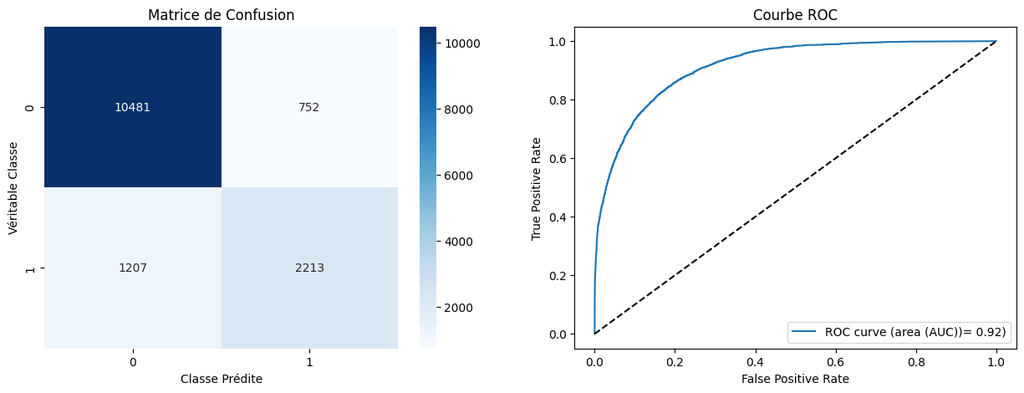

```python
# Prédiction sur l'ensemble de test
y_pred = best_rf.predict(X_test)

# Calcul de la précision (Accuracy)
accuracy = accuracy_score(y_test, y_pred)
print(f"Accuracy: {accuracy:.2f}")

# Rapport de classification
print("Classification Report:")
report = classification_report(y_test, y_pred, output_dict=True)
report_df = pd.DataFrame(report).transpose()
display(report_df)

plt.figure(figsize=(15, 5))
plt.subplot(1, 2, 1)

# Matrice de confusion
conf_matrix = confusion_matrix(y_test, y_pred)
sns.heatmap(conf_matrix, annot=True, fmt='d', cmap='Blues')
plt.title('Matrice de Confusion')
plt.xlabel('Classe Prédite')
plt.ylabel('Véritable Classe')

# Calcul de l'AUC
y_pred_proba = best_rf.predict_proba(X_test)[:, 1]
auc = roc_auc_score(y_test, y_pred_proba)

plt.subplot(1, 2, 2)

# Tracé de la courbe ROC
fpr, tpr, _ = roc_curve(y_test, y_pred_proba)
plt.plot(fpr, tpr, label=f'ROC curve (area (AUC))= {auc:.2f})')
plt.plot([0, 1], [0, 1], 'k--')
plt.xlabel('False Positive Rate')
plt.ylabel('True Positive Rate')
plt.title('Courbe ROC')
plt.legend(loc="lower right")
plt.show()
```

Les résultats du modèle sont satisfaisants. Le fonctionne bien en général, avec une bonne capacité à distinguer les deux classes de revenu. Les performances pour la classe de revenu >50K (classe 1) sont bonnes. Cependant, il y a encore de la place pour améliorer le rappel pour cette classe, ce qui pourrait impliquer de regarder plus en détail les caractéristiques des individus qui sont actuellement classés à tort comme ayant un revenu <=50K (faux négatifs), ou de considérer d'autres techniques de modélisation ou de rééquilibrage des classes.

Pour notre cas, cette précision nous suffira.

Passons maintenant à la visualisation des caractéristiques les plus importantes dans la prédiction du modèle.

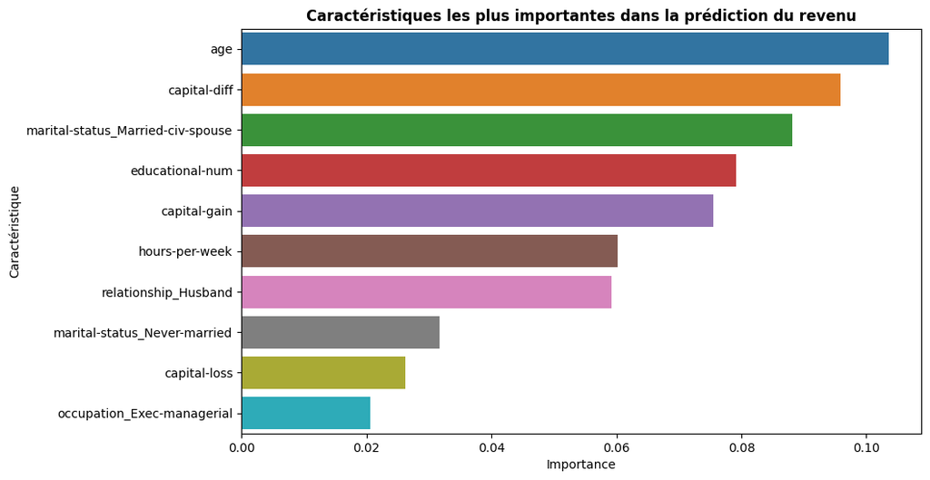

```python
# Calcul de l'importance des caractéristiques
feature_importances = best_rf.feature_importances_

# Création d'un DataFrame pour stocker les features et leur importance
features_df = pd.DataFrame({'Feature': X_train.columns, 'Importance': feature_importances})

# Tri des features par importance décroissante
top_features_df = features_df.sort_values(by='Importance', ascending=False).head(10)

# Affichage des 10 features les plus importants
plt.figure(figsize=(10, 6))
sns.barplot(x='Importance', y='Feature', data=top_features_df, hue='Feature')
plt.title('Caractéristiques les plus importantes dans la prédiction du revenu', weight='bold')
plt.xlabel('Importance')
plt.ylabel('Caractéristique')
plt.show()
```

On voit donc ici les caractéristiques sur lesquels le modèle s'est le plus basé pour prédire ses résultats. On note donc qu'aucune d'entre elles n'a de valeurs extrêmement élevée, ce qui prouve que le revenu d'une personne est corrélé à de nombreux facteurs, comme nous pouvions nous y attendre.

Par ailleurs, certains champs, tels que l'âge, le nombre d'années d'études, le temps de travail ou le gain de capital semble être liés au fait de toucher un revenu supérieur à 50k.

Visualisons donc maintenant les relations entres ces champs et le niveau de revenu.

### 6.2. Visualisation des interactions entre facteurs influents

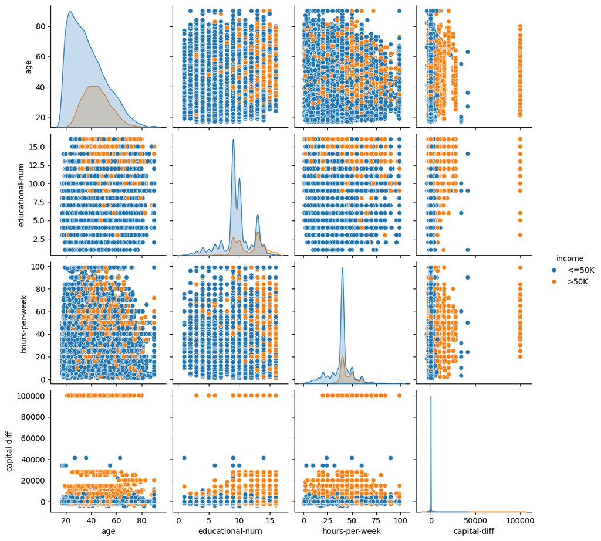

```python
# Utilisation de pairplot pour visualiser les interactions entre quelques-unes des caractéristiques les plus importantes
selected_features = ['age', 'educational-num', 'hours-per-week', 'capital-diff']
sns.pairplot(adult_df, vars=selected_features, hue='income')
plt.show()
```

Des patterns intéressants émergent, tels que l'augmentation des revenus avec l'âge et l'éducation, et le lien du gain de capital avec un revenu supérieur à 50k. Ces visualisations soulignent l'importance de considérer les interactions entre différentes caractéristiques.

## 7. Conclusion et synthèse

#### Structure et caractéristiques du jeu de données

Le dataset comprend un mélange de caractéristiques **numériques** et **catégorielles**, offrant un aperçu de divers aspects socio-économiques de la population d'adultes. Les caractéristiques incluent, mais ne sont pas limitées à, l'âge, l'éducation, la profession, la couleur de peau, le sexe et le revenu.

#### Avantages et points forts

- **Richesse des informations :** Le dataset fournit une mine d'informations pour des analyses approfondies sur les disparités de revenu.
- **Applicabilité :** Les données sont extrêmement pertinentes pour les études sur les inégalités économiques et les politiques sociales.

#### Inconvénients et limites

- **Pondération `fnlwgt` :** L'utilisation de la pondération complexifie certaines analyses, notamment les visualisations et les modèles statistiques.
- **Manque de contexte temporel :** L'absence d'informations temporelles limite la capacité d'analyser les tendances au fil du temps.
- **Données manquantes :** La présence de valeurs manquantes peut introduire des biais dans l'analyse.

#### Relations et interdépendances entre les champs

Des corrélations et interactions significatives entre des caractéristiques telles que l'éducation, l'âge, les heures de travail et le revenu ont été observées, indiquant l'importance de ces facteurs dans la détermination des niveaux de revenu.

#### Informations et études potentielles

- **Études sur l'équité socio-économique :** Le dataset peut servir de base pour examiner les disparités de revenu à travers différentes catégories démographiques.
- **Planification et politiques sociales :** Les insights peuvent éclairer les décideurs sur les domaines à cibler pour réduire les inégalités.
- **Recherches futures :** L'exploration de modèles plus complexes et de techniques analytiques avancées pourrait fournir une compréhension plus approfondie des dynamiques sous-jacentes.

Cette analyse exploratoire a fourni des insights précieux sur la structure socio-économique d'une population d'adultes, tout en mettant en lumière les opportunités et les défis associés à l'interprétation de telles données. Elle ouvre la voie à des recherches plus approfondies et à des analyses plus ciblées pour explorer les multiples facettes des inégalités de revenu.